# Best Distribution for D'

Reproduce the class for the simulated distributions for D'

```python
import numpy as np
import matplotlib.pyplot as plt
%matplotlib inline
import pandas as pd
import seaborn as sns
```

```python
class Population(object):

    def __init__(self,N,Dmin=0,Dmax=800,m=2.6,r0=50.0,a=1.1):
        assert (m<3)
        self.N = N
        self.m = m
        self.Dmin = Dmin
        self.Dmax = Dmax

        #set a set of random numbers to do a distribution of Ds
        #I think D is such that n ~ D^-m
        xi = np.random.random_sample((N,))
        x0 = Dmin/Dmax
        self.D = Dmax*((1 - x0**(3.0 - m))*xi + x0**(3.0 - m))**(1.0/(3.0 - m))

        #Set of mu -> [-1,1]
        xi = np.random.random_sample((N,))
        self.mu = 2*xi - 1.0

         # Inclination to plane of sky inc = [-90:90]
        self.inc = np.degrees(np.arcsin(self.mu))

        # Projected distance
        self.Dprime = self.D*np.sqrt(1.0 - self.mu**2)

        # Now for position angle
        xi = np.random.random_sample((N,))
        self.PA = 360.0*xi

        # Plane-of-sky coords (Right Ascention and Declination)
        self.Dec = self.Dprime*np.cos(np.radians(self.PA))
        self.RA = self.Dprime*np.sin(np.radians(self.PA))
        #Distribution of proplyd sizes in AU
        rmax = 6*self.D
        b = 1.0 - 1.0/(1.0+(rmax/r0)**(2*a))
        xi = np.random.random_sample((N,))
        self.rAU = r0*((1.0/(1.0-b*xi))-1.0)**(1./(2*a))
```

The next steps will be:

- Obtain HA 98 Data, Ricci data and/or other else
- Obtain the best model via chi square minimization

Start with Henney & Arthur 1998 data

```python
from astropy.table import Table
```

```python
datafile = "Proplyd-Datasets/vicente-vs-HA98.dat"
data = Table.read(datafile, format='ascii')
```

```python
data
```

| ID | d | r14 | VicR14 |
| --- | --- | --- | --- |
| 163-323 | 2.14 | 2.2 | 19.4 |
| 161-324 | 6.05 | 3.5 | 25.8 |
| 168-328 | 6.64 | 2.8 | 21.0 |
| 163-317 | 6.91 | 5.0 | 27.1 |
| 166-316 | 7.01 | 2.5 | 14.8 |
| 161-328 | 7.74 | 9.1 | 20.0 |
| 167-317 | 7.83 | 7.9 | 35.8 |
| 158-323 | 9.42 | 6.3 | 30.6 |
| 158-326 | 9.6 | 11.3 | 31.6 |
| 161-314 | 10.24 | 5.3 | 17.1 |
| 158-327 | 10.6 | 16.6 | 35.5 |
| ... | ... | ... | ... |
| 153-321 | 16.97 | 1.2 | 8.4 |
| 159-338 | 17.2 | 5.0 | 13.5 |
| 171-340 | 19.11 | 23.3 | 23.2 |
| 152-319 | 19.16 | 18.2 | 14.8 |
| 155-338 | 20.48 | 17.0 | 29.7 |
| 173-341 | 22.48 | 4.1 | 18.1 |
| 180-331 | 25.12 | 12.2 | 29.3 |
| 177-341 | 25.84 | 20.4 | 51.6 |
| 159-350 | 28.35 | 20.1 | 44.5 |
| 182-413 | 56.7 | 36.9 | 48.7 |
| 244-440 | 142.3 | 104.0 | 180.6 |

```python
HA_D = data["d"]
```

```python
MC_D = Population(28,Dmin = 2.1,Dmax= 150)
```

Now, it's time to define our $\chi^2$ function

```python
def chi_sq(data,model):
    ch2 = 0
    for d,m in zip(data,model):
        ch2 += (d-m)**2/m
    return ch2
```

```python
chi2 = chi_sq(sorted(HA_D),sorted(MC_D.Dprime))
```

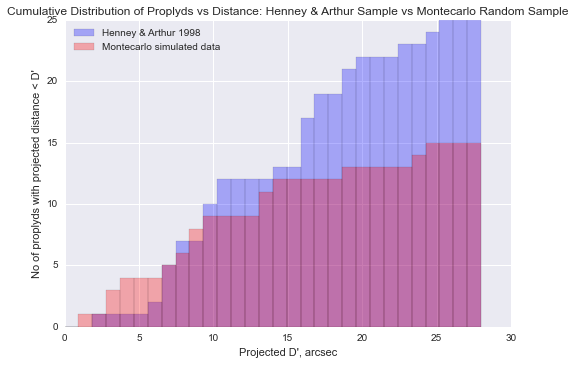

```python
plt.hist(HA_D,bins = 30,range = (0,28),cumulative = True,color="b",alpha=0.3,label = "Henney & Arthur 1998")
plt.hist(MC_D.Dprime,bins=30,range=(0,28),cumulative=True,color="r",alpha=0.3,label = "Montecarlo simulated data")
plt.xlabel("Projected D', arcsec")
plt.ylabel("No of proplyds with projected distance < D'")
plt.title("Cumulative Distribution of Proplyds vs Distance: Henney & Arthur Sample vs Montecarlo Random Sample")
plt.legend(loc="upper left")
```

The next step is to found a value for m that minimizes $\chi^2$

```python
M = np.linspace(0.1,2.7,500)
x2 = []
for m in M:
    model = Population(28,Dmin=2,Dmax=150,m=m)
    sq = chi_sq(HA_D,model.Dprime)
    x2.append(sq)
```

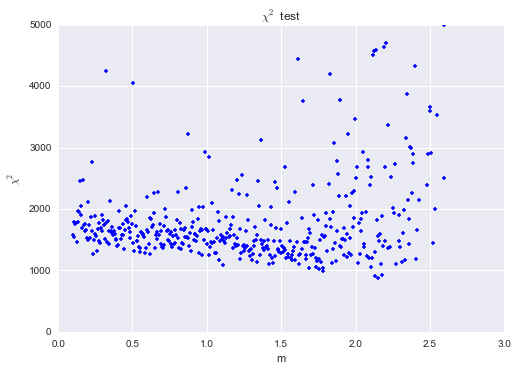

```python
plt.plot(M,x2,"b.")
#plt.xlim(0,2.5)
plt.ylim(0,5000)
plt.xlabel("m")
plt.ylabel(r"$\chi^2$")
plt.title(r"$\chi^2$ test")
```

A juzgar por el test y considerando el ruido que tiene, parece que el mejor ajuste ronda entre 2 y 2.5. El ajuste sigue siendo malo, pero todavía necesita ajustes

```python
pop_2 = Population(28,Dmin=2,Dmax=150,m=2.4)
MC_D2 = pop_2.Dprime
```

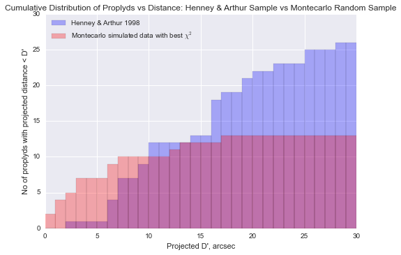

```python
plt.hist(HA_D,bins = 30,range = (0,30),cumulative = True,color="b",alpha=0.3,label = "Henney & Arthur 1998")
plt.hist(MC_D2,bins=30,range=(0,30),cumulative=True,color="r",alpha=0.3,label =
         r"Montecarlo simulated data with best $\chi^2$")
plt.xlabel("Projected D', arcsec")
plt.ylabel("No of proplyds with projected distance < D'")
plt.title("Cumulative Distribution of Proplyds vs Distance: Henney & Arthur Sample vs Montecarlo Random Sample")
plt.legend(loc="upper left")
```

# Try to obtain $\beta$ models for large distances

```python
from astropy.constants import c,m_p, Ryd, L_sun, M_sun
from astropy.constants import h as hplanck
import astropy.units as u
```

```python
QH = 1e49/u.s # ionizing photon flux
d_orion = 430 # distance to orion in parsecs
alpha_B = 2.6e-13*u.cm**3/u.s #recombination rate of hydrogen to all levels except n=1
alpha_ha = 1.0e-13*u.cm**3/u.s # recombination rate of H alpha?
omega = 0.1 # effective thickness of photoevaporated layer in terms of the ioniztion front radius
ci = 11.0*u.km/u.s # ionized sound speed
m = (1.3*u.u).to(u.g) #mean mass per particle
E_ha = (hplanck*c/(6563.0*u.angstrom)).to(u.erg)
```

Create a large set of simulated populations

```python
mega_datasets = []
for _ in range(30000):
    p = Population(190,m=2.1,Dmin=5.0,Dmax=250.0)
    mega_datasets.append(p)
```

try with dataset number 2000

```python
iset = 2000
p = mega_datasets[2000]
D = (p.D*d_orion*u.au).to(u.cm)
r = (p.rAU*u.AU).to(u.cm)
ntilde = ci/(2*alpha_B*omega*r)
```

Two models for Ionizing Flux: Only the flux coming from star and other flux + recombinations to ground state

Model without recombinations

```python
F1 = QH/(4.0*np.pi*D**2)
n1 = np.sqrt(ntilde**2+F1/(alpha_B*omega*r))-ntilde
lambda1 = ci*n1/F1
L1_ha = E_ha*alpha_ha*r**3*n1**2
S1_ha = E_ha*alpha_ha*r*n1**2/(4.*np.pi*u.steradian)
M1dot = (n1*ci*m*4*np.pi*r**2).to(u.solMass/u.year)
M1dot.mean()
```

$1.59293\times 10^{-07} \; \mathrm{\frac{M_{\odot}}{yr}}$

Plot advection parameter $\lambda = \frac{n_0u_0}{F}$ vs $H\alpha$ luminosity

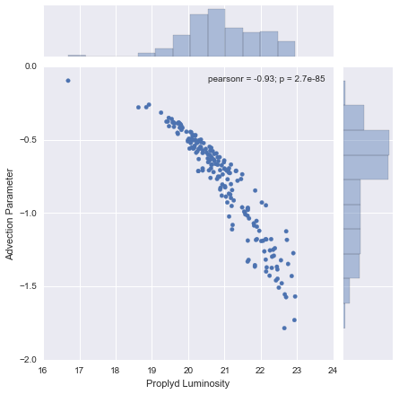

```python
g = sns.jointplot(np.log10(L1_ha.value),np.log10(lambda1))
g.ax_joint.set_ylabel(r"Advection Parameter")
g.ax_joint.set_xlabel(r"Proplyd Luminosity")
```

Now surface brightness versus distance

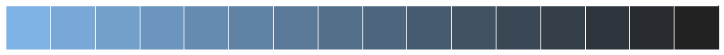

```python
rootcolor=(0.5,0.7,0.9)
ncolors=16
darkmap = sns.dark_palette(rootcolor,ncolors,reverse=True,as_cmap=True)
sns.palplot(sns.dark_palette(rootcolor,ncolors,reverse=True))
```

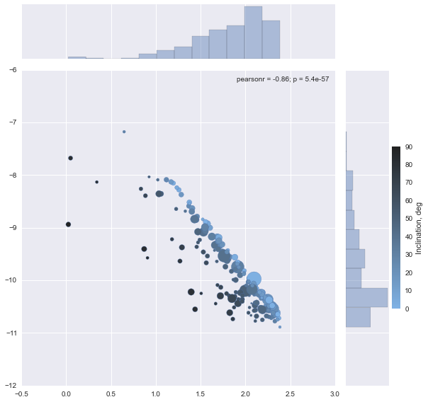

```python
inc = np.abs(p.inc)
g = sns.jointplot(np.log10(p.Dprime),np.log10(S1_ha.value),joint_kws={"s":p.rAU,"c":inc,
                                        "vmin":0.0,"vmax":90.0,"cmap":darkmap},size=8)
q = plt.colorbar()
q.set_label("Inclination, deg")
```

Try with regplot, plotting a linear regression

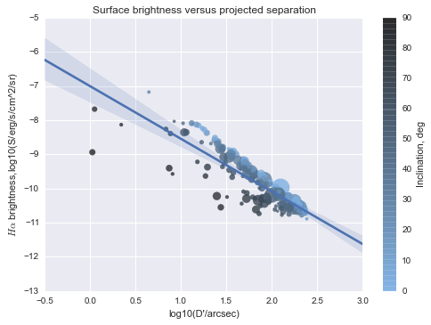

```python
g = sns.regplot(np.log10(p.Dprime),np.log10(S1_ha.value),order=1,robust=False,
                scatter_kws={"s":p.rAU,"c":inc,"vmin":0.0,"vmax":90.0,"cmap":darkmap})
cb = plt.colorbar(g.collections[0],ax=g)
cb.set_label("Inclination, deg")
g.set_xlabel("log10(D'/arcsec)")
g.set_ylabel(r"$H\alpha$ brightness,log10(S/erg/s/cm^2/sr)")
g.set_title("Surface brightness versus projected separation")
```

controlling for inclination as a confounding variable

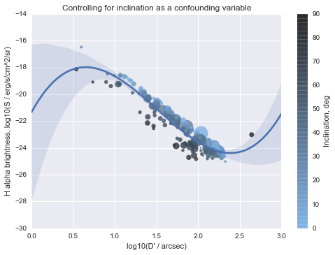

```python
x = p.Dprime
y = S1_ha
z = p.rAU
g = sns.regplot(np.log10(x),np.log(y.value),order =3,x_partial=1.0/np.cos(np.radians(inc)),
                y_partial=1.0/np.cos(np.radians(inc)),scatter_kws={"s":z,
                "c":inc,"vmin":0.0,"vmax":90.0,"cmap":darkmap})
cb = plt.colorbar(g.collections[0],ax=g)
cb.set_label("Inclination, deg")
g.set_xlabel("log10(D' / arcsec)")
g.set_ylabel("H alpha brightness, log10(S / erg/s/cm^2/sr)")
g.set_title("Controlling for inclination as a confounding variable")
```

Now it is time for the mass loss rate. Do a test with only one plot

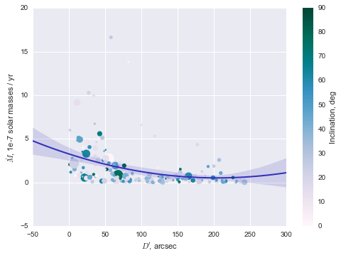

```python
scatter_kws = dict(marker="o",alpha=1.0,edgecolors=None)
line_kws = dict(lw=2)
g = sns.regplot(x,M1dot/1.e-7,order=2,ci=90,color = "#3030BC",
                    scatter_kws=color_kws,line_kws=line_kws)
g.set_xlabel("$D'$, arcsec")
g.set_ylabel(r'$\dot{M}$, 1e-7 solar masses / yr')
cb = plt.colorbar(g.collections[0])
cb.set_label("Inclination, deg")
```

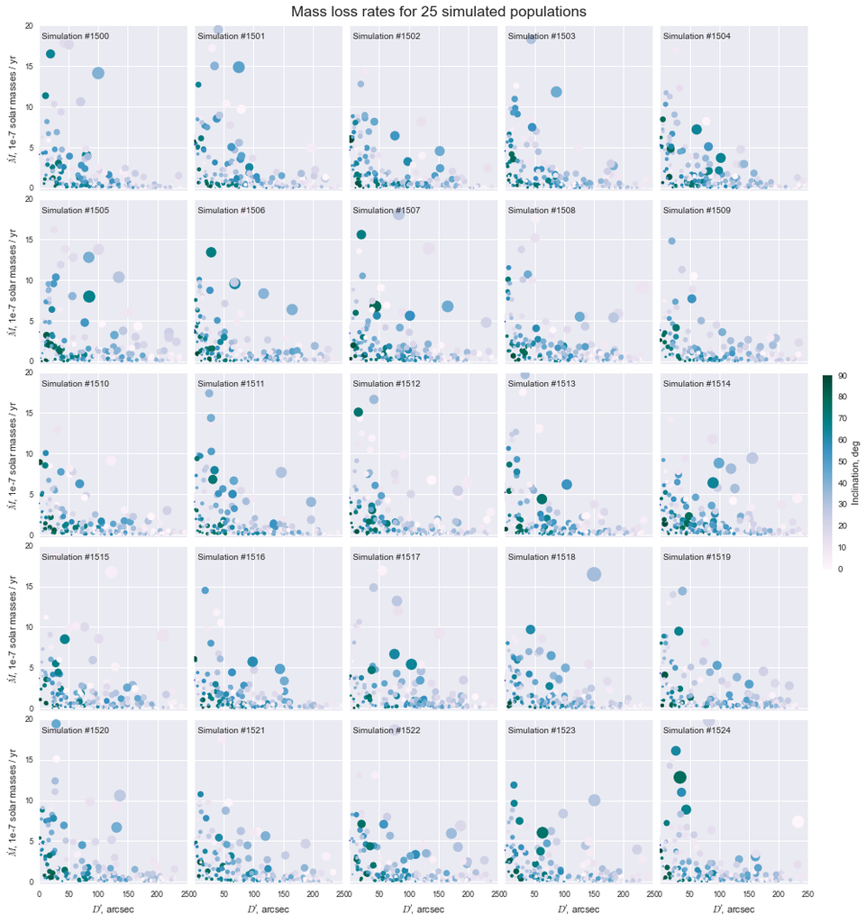

```python
istart = 1500
scatter_kws = dict(marker="o",alpha=1.0,edgecolors=None)
line_kws = dict(lw=2)
fig, axes = plt.subplots(5,5,sharex=True,sharey=True)
i=istart
for p,ax in zip(mega_datasets[istart:istart+25],axes.flat):
    D = (p.D*d_orion*u.au)
    F = QH/(4*np.pi*D**2)
    r = (p.rAU*u.AU).to(u.cm)
    ntilde = ci/(2*alpha_B*omega*r)
    n = np.sqrt(ntilde**2+F/(alpha_B*omega*r))-ntilde
    Mdot = (n*ci*m*4*np.pi*r**2).to(u.solMass/u.year)

    color_kws = scatter_kws.copy()
    color_kws.update(c=np.abs(p.inc),s=0.5*p.rAU,cmap ="PuBuGn",vmin=0.0,vmax=90.0)
    g = sns.regplot(p.Dprime,Mdot/1.e-7,ax=ax,order=2,ci=90,color = "#3030BC",
                    scatter_kws=color_kws,line_kws=line_kws)
    ax.text(0.02,0.92,"Simulation #{}".format(i),transform = ax.transAxes)
    i+= 1

for ax in axes[-1, :]:
    ax.set_xlabel("$D'$, arcsec")
for ax in axes[:, 0]:
    ax.set_ylabel(r'$\dot{M}$, 1e-7 solar masses / yr')
for ax in axes.flat:
    ax.tick_params(axis='both', which='major', labelsize=9)
    ax.set_xlim(0.0, 250.0)
    ax.set_ylim(-0.3, 20.0)

cb = plt.colorbar(g.collections[0], ax=list(axes.flat), shrink=0.25, fraction=0.02)
cb.set_label("Inclination, deg")
fig.suptitle("Mass loss rates for 25 simulated populations", fontsize='xx-large')
fig.subplots_adjust(left=0.1, right=0.87, bottom=0.1, top=0.96, wspace=0.05, hspace=0.05)
fig.set_size_inches(16, 16)
```

Repeat the same exercise inluding the recombinations in the flux term

The idea is the next: In ionization balance, the total flux of ionizing radiation is given by: \begin{equation} N = \int^{\infty}_{\nu_T} N(\nu) exp[-\tau(\nu,r)]~d\nu \end{equation}

Where: $N(\nu) = \frac{L_*(\nu)}{4\pi r^2 h\nu}$

$\tau(\nu,r) = \int^{r}_{0}\alpha_H(\nu)n_H(r')~dr'$

$L_*$ is the star luminosity, $\alpha_H$ is the ionization cross section for hydrogen, $n_H$ is the density and $\tau$ is the optical depth

The total photons emmited by the star is given by:

\begin{equation} N_{Lyc} = \int^{\infty}_{\nu_T} \frac{L_*(\nu)}{h\nu}~d\nu \end{equation}

Where $\nu_T$ is the frequency at the threshold, i.e, the minimal frequency to ionize hydrogen. For small optical depth, we can do the following: \begin{equation} N = \int^{\infty}_{\nu_T} N(\nu)(1-\tau(\nu,r))~d\nu \end{equation}

Assuming constant density, we get:

\begin{equation} N\simeq \frac{1}{4\pi r^2}\int^{\infty}_{\nu_T}\frac{L_*(\nu)}{h\nu}~d\nu -\frac{n_H}{4\pi r}\int^{\infty}_{\nu_T} \frac{L_*(\nu)\alpha_H(\nu)}{h\nu}~d\nu \end{equation}

\begin{equation} N \simeq \frac{N_{Lyc}}{4\pi r^2} - \frac{n_H}{4\pi r}\int^{\infty}_{\nu_T}\frac{L_*(\nu)\alpha_H(\nu)}{h\nu}~d\nu \end{equation}

Now, the averaged cross section for hydrogen is defined as:

\begin{equation} \bar{\alpha}_H \equiv \frac{1}{N} \int^{\infty}_{\nu_T}\frac{L_*(\nu)}{4\pi r^2 h\nu}\alpha_H(\nu)~d\nu \end{equation}

Then: \begin{equation} N \simeq \frac{N_{Lyc}}{4\pi r^2}- N\bar{\alpha}_H n_H r \end{equation}

Finally: \begin{equation} N \simeq \left(\frac{N_{Lyc}}{4\pi r^2}\right)\left(1-\bar{\alpha}_H n_H r\right) \end{equation}

For a typical HII region, $\bar{\alpha}_H = 3 \times 10^{-19}~\mathrm{cm^2}$

Sounds good, except that the quantity $\bar{\alpha}_H n_H r$ is not small, so this approximation does not work (or at least it seems so). Now, it's time to try a new approach.

Since, the taylor series for the exponential in the expression for $N$ didn't work, we won't use it anymore. Intead of that, we will use the expression for $\bar{\alpha}_H$, but solving for $N$

\begin{equation} N = \frac{1}{4\pi r^2 \bar{\alpha}_H}\int^{\infty}_{\nu_T}\frac{L_*}{h\nu} \alpha_H~d\nu \end{equation}

Now, we need explicit expressions for $L_*$ and $\alpha_H$. $\alpha_H$ can be approximated as $\alpha_H \simeq \alpha_0 \left(\frac{\nu_T}{\nu}\right)^3$, where $\alpha_0$ is the hydrogen cross section at the threshold. And $L_*$ is a blackbody with temperature $T_*$. So the expression for $L_*$ is the planck law integrated over the star surface

\begin{align} L_* = 4\pi R^2_* B_\nu = 4\pi R^2_* \frac{2h\nu^3}{c^2}\frac{1}{\exp[\frac{h\nu}{kT_*}]-1} \end{align}

With this, the expression for $N$ becomes:

\begin{equation} N \simeq \frac{2\alpha_0 R^2_*\nu^3_T}{r^2c^2\bar{\alpha}_H} \int^{\infty}_{\nu_T} \nu^{-1}\exp\left[-\frac{h\nu}{KT_*}\right]~d\nu \end{equation}

This approximation can be done since the thershold frequency $\nu_T$ is in the ultraviolet regime, therefore we are integrating over high values for $\nu$.

Now we do a change of variable $x = \frac{h\nu}{kT_*}$ to get an adimensional integral:

\begin{equation} N \simeq \frac{2\alpha_0 R^2_*\nu^3_T}{r^2c^2\bar{\alpha}_H} \int^{\infty}_{x_T} x^{-1}\exp[-x]~dx \end{equation}

where $x_T = \frac{h\nu_T}{kT_*}$. For a O9 star, $x_T=4.7$ and for a O7 star, $x_T = 3.84$, so we can use $x_T = 4$

```python
alpha_av = 3e-19*u.cm**2
#F2 = (QH/(4.0*np.pi*D**2))*(1.-alpha_av*D*ntilde) #First approximation?
#n2 = np.sqrt(ntilde**2+F2/(alpha_B*omega*r))-ntilde
#lambda2 = ci*n1/F1
#L2_ha = E_ha*alpha_ha*r**3*n2**2
#S2_ha = E_ha*alpha_ha*r*n2**2/(4.*np.pi*u.steradian)
#M2dot = (n2*ci*m*4*np.pi*r**2).to(u.solMass/u.year)
```

```python
from astropy.constants import R_sun
import scipy.integrate as sci
alpha_0 = 6.3e-18*u.cm**2
nuT = 3.29e15/u.s
Rs = 80*R_sun
xT = 4.0
inf=float("inf")
f = sci.quad(lambda x:np.exp(-x)/x,xT,inf)
intnum = f[0]
```

```python
F2 = 2*nuT**3*alpha_0*intnum*Rs**2/(D**2*c**2*alpha_av)
```

```python
#F2.to(1/(u.cm**2*u.s))
#F1
(F2.to(1/(u.cm**2*u.s))/F1).mean()
```

$4528.4 \; \mathrm{}$

The new flux looks like is three orders of magnitude higher than the flux without considering recombinations. Let's see if it makes sense. Reconstructing the previos calculations. We find that:

```python
n2 = np.sqrt(ntilde**2+F2/(alpha_B*omega*r))-ntilde
lambda2 = ci*n1/F1
L2_ha = E_ha*alpha_ha*r**3*n2**2
S2_ha = E_ha*alpha_ha*r*n2**2/(4.*np.pi*u.steradian)
M2dot = (n2*ci*m*4*np.pi*r**2).to(u.solMass/u.year)
```

```python
M2dot.mean()
```

$3.02415\times 10^{-06} \; \mathrm{\frac{M_{\odot}}{yr}}$

The mass loss rate obtained seems reasonable

Let's do the rest of the job

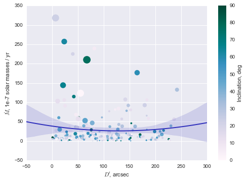

```python
scatter_kws = dict(marker="o",alpha=1.0,edgecolors=None)
line_kws = dict(lw=2)
g = sns.regplot(x,M2dot/1.e-7,order=2,ci=90,color = "#3030BC",
                    scatter_kws=color_kws,line_kws=line_kws)
g.set_xlabel("$D'$, arcsec")
g.set_ylabel(r'$\dot{M}$, 1e-7 solar masses / yr')
cb = plt.colorbar(g.collections[0])
cb.set_label("Inclination, deg")
```